# Checking formulae for GxE in families

Andrey Ziyatdinov

2017-01-13

# 1 About

OLS solutions for (genetic) marginal and (gene-environmental) interaction effects are well known:

- $\hat{\beta_g} \sim (\beta_g, \frac{\sigma_e^2}{g_c^Tg_c}) \approx (\beta_g, \frac{\sigma_e^2}{N\sigma_g^2})$, where $g_c$ is centered genotype vector.
- $\hat{\beta_{ge}} \sim (\beta_{ge}, \frac{\sigma_e^2}{ge_c^T ge_c}) \approx (\beta_{ge}, \frac{\sigma_e^2}{\sigma_g^2 \sigma_e^2})$, where $ge_c$ is vector of interaction effect derived from two *centered* genotype and environment vectors.

How these formulas will change in the presence of random effects in the LMM framework?

The jump from OLS to LMM is hard. So, we study an intermediate case of GLS under two scenarios:

1. Common random effect, e.g. shared environment.
   - The genotypes are distributed independently among samples.
2. Genetic random effect.
   - The genotypes have a covariance matrix, e.g. the double kinship for the additive genetic model.

*Note*: In the case of GLS the values for variance components (to derive the matrix $\hat{V}$) are exactly the same as those used in data simulation process. That helps us to avoid situations when the variance components are not precisely estimated by REML in LMM.

## 1.1 Exact formulas and approximations

BLUP will be used for the exact formulas.

Approximation of the exact formulas will make use of:

- Known distribution of genotypes (and environment), e.g. the Bernoulli distribution.
- The mean and variance of the quadratic forms $x^T A x$.
  - In our case, the matrix $A$ is the inverse of variance-covariance matrix $\hat{V}^{-1}$.

*Note*: one underestimates the variance of $\beta$ in LMM using $\hat{V}$ , as the variance of variance components $\sigma^2_i$ is not taken into account.

## 1.2 Simulations

Each model was repeated 100 times, and the sample size varied as 100, 1,000, 5,000 and 10,000.

The MAF $p$ was set to 0.3. The frequency of exposure $f$ was 0.4.

The effect size for both marginal and interaction effects was 0.1

## 1.3 R code

An additional package wls has been developed to run GLS.

The gxefam package was used for data simulation.

The true parameter estimates were extracted from outputs of the `lm` R function.

## 1.4 Current status

| Test | OLS | GLS (common) | GLS (genetic) | LMM (common) | LMM (genetic) |
| --- | --- | --- | --- | --- | --- |
| Marginal `y ~ g` | success | success | success |  |  |
| Interaction `y ~ g + e + g:e` | success | failure |  |  |  |

**success** means that the relative error between the exact and approximate solution is below 1% at sample size of 10,000.

## 1.5 Summary

### 1.5.1 Preliminary notes

- The general formula for effect variance is $\frac{\sigma_{sc}^2}{g_c^T \hat{V}^{-1} g_c}$.
  - It can be rewritten as $\frac{\sigma_{sc}^2}{{g^{*}_c}^T g^{*}_c}$, where $g^{*}_c$ is a transformation of the original vector defined as $g^{*}_c = \hat{V}^{-0.5} g_c$.
  - It seems that $var(g^{*}_c) = var(g^{*})$, where $g^{*} = \hat{V}^{-0.5} g$. Is that right?
- When passing from LMM to GLS, the residual variance has to be 1, but it can be slightly different from 1, because the way we compute GLS: we call directly the R `lm` function rather than using the matrix formulas. Consequently, there is no an obvious way to set the residual variance to 1 when calling `lm`.
  - The residual variance is GLS is noted as $\sigma_{sc}$, and it is roughly equal to 1.

### 1.5.2 Variance of a marginal effect

| Study | OLS/GLS Model | Genotype $g$ | Variance of $\hat{\beta_g}$ | Approximation | Error |
| --- | --- | --- | --- | --- | --- |
| Independent samples | $y \sim (\mu + \beta_g g, \sigma_e^2 I)$ | $g \sim (pq, 2pq I)$ | $\frac{\sigma_e^2}{g_c^T g_c}$ | $\frac{\sigma_e^2}{2pq N}$ | $\approx$ 1% |
| Common random effect | $y \sim (\mu + \beta_g g, \hat{\sigma}_f^2 F + \hat{\sigma}_e^2 I)$ $y \sim (\mu + \beta_g g, \sigma_{sc}^2 \hat{V})$ | $g \sim (pq, 2pq I)$ | $\frac{\sigma_{sc}^2}{g_c^T \hat{V}^{-1} g_c}$ | $\frac{\sigma_{sc}^2}{2pq \mbox { } trace(\hat{V}^{-1})} = \frac{\sigma_{sc}^2}{2pq \mbox { } \sum_i{(\hat{\sigma}_f^2 \lambda_{F}^i + \hat{\sigma}_e^2)^{-1}}}$ | $\approx$ 1% |
| Genetic random effect | $y \sim (\mu + \beta_g g, \hat{\sigma}_g^2 K + \hat{\sigma}_e^2 I)$ $y \sim (\mu + \beta_g g, \sigma_{sc}^2 \hat{V})$ | $g \sim (pq, 2pq K)$ | $\frac{\sigma_{sc}^2}{g_c^T \hat{V}^{-1} g_c}$ | $\frac{\sigma_{sc}^2}{2pq \mbox { } trace(\hat{V}^{-1}K)} = \frac{\sigma_{sc}^2}{2pq \mbox { } \sum_i{(\hat{\sigma}_g^2 + \hat{\sigma}_e^2 (\lambda_{K}^i)^{-1})^{-1}}}$ | $\approx$ 1% |

| Study | LMM/GLS Model | Genotype $g$ | Variance of $\hat{\beta_g}$ | Approximation | Error |
| --- | --- | --- | --- | --- | --- |
| Common random effect | $y \sim (\mu + \beta_g g, \sigma_f^2 F + \sigma_e^2 I)$ $y \sim (\mu + \beta_g g, \sigma_{sc}^2 \hat{V})$ | $g \sim (pq, 2pq I)$ | $\frac{\sigma_{sc}^2}{g_c^T \hat{V}^{-1} g_c}$ | $\frac{\sigma_{sc}^2}{2pq \mbox { } trace(\hat{V}^{-1})} = \frac{\sigma_{sc}^2}{2pq \mbox { } \sum_i{(\hat{\sigma}_f^2 \lambda_{F}^i + \hat{\sigma}_e^2)^{-1}}}$ | TBA |
| Genetic random effect | $y \sim (\mu + \beta_g g, \sigma_g^2 K + \sigma_e^2 I)$ $y \sim (\mu + \beta_g g, \sigma_{sc}^2 \hat{V})$ | $g \sim (pq, 2pq K)$ | $\frac{\sigma_{sc}^2}{g_c^T \hat{V}^{-1} g_c}$ | $\frac{\sigma_{sc}^2}{2pq \mbox { } trace(\hat{V}^{-1}K)} = \frac{\sigma_{sc}^2}{2pq \mbox { } \sum_i{(\hat{\sigma}_g^2 + \hat{\sigma}_e^2 (\lambda_{K}^i)^{-1})^{-1}}}$ | TBA |

## 1.6 Propositions from linear algebra

### 1.6.1 Quadratic forms

If $x$ is a vector of random variables, the quadratic form $x^TAx$ is a scalar random variable.

If $x$ has mean $\mu$ and (nonsingular) covariance matrix $V$, then

$E(x^TAx) = tr(AV) + \mu^T A \mu$

$\sigma^2(x^TAx) = 2tr(AVAV) + 4\mu AVA \mu$

See (Lynch and Walsh 1998, Appendix 3, pp. 843) for more details.

### 1.6.2 EVD and inverse matrices

If

- $K$ is the covariance matrix
  - $K$ is a symmetric matrix and its EVD is $K = Q D Q^{-1} = Q D Q^T$
  - $K$ is positive semi-definite, that means all its EVs are non-negative
- $V = aK + bI$

then for power series:

- $K^{-1} = Q D^{-1} Q^T$
- $K^{-0.5} = Q D^{-0.5} Q^T$

for sum with the identity matrix:

- $V = aK + bI = a Q D Q^{-1} + b I = a Q D Q^{-1} + b Q I Q^{-1} = Q (aD + bI) Q^{-1}$

for computing inverse matrices using EVD:

- $V^{-1} = Q (aD + bI)^{-1} Q^{-1}$

for traces:

- $tr(K) = \sum{\lambda^i_K}$
- $tr(K^{-1}) = \sum{(\lambda^i_K)^{-1}}$
- $tr(V) = \sum{(a \lambda^i_K + b)}$
- $tr(V)^{-1} = \sum{(a \lambda^i_K + b)^{-1}}$

additionally, for inverse of sum of two matrices:

- $(aK + bI)^{-1} K = (aK + bI)^{-1} (K^{-1})^{-1} = K^{-1} (aK + bI)^{-1} = (aI + bK^{-1})^{-1}$
- $tr((aK + bI)^{-1} K) = \sum{(a + b (\lambda^i_K)^{-1})^{-1}} = \sum{\frac{\lambda^i_K}{a \lambda^i_K + b}}$

# 2 OLS for marginal effect

| Type | Notation | Description | R code |
| --- | --- | --- | --- |
| Exact | `mod` | Output of `lm` | `vcov(mod)["g", "g"]` |
| Approximate | `form_var` | $\frac{\sigma_{e}^2}{N \sigma_g^2}$ | `s2 / (N*var(g))` |
| Approximate | `form_g` | $\frac{\sigma_{e}^2}{N 2pq}$ | `s2 / (N*2*p*1)` |

The relative errors on the second plot are computed in respect to the exact solution, which is output of `lm`.

Note that `form_var` is approximate here, because $var(g) = (g_c^T g) / (N-1) \approx (g_c^T g) / N$. Anyway, it is a good control under how the relative error is decreasing with increasing sample size, i.e. the rate must be proportional to `1/N`.

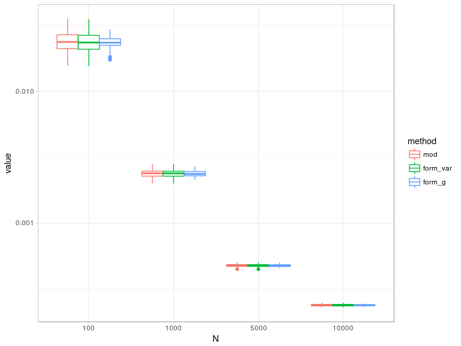

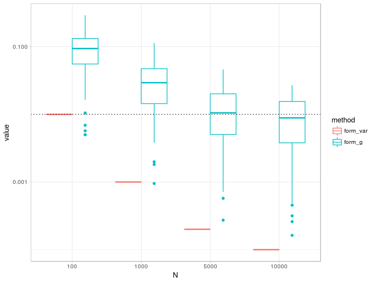

# 3 GLS for marginal effect

## 3.1 General case

### 3.1.1 Model

$var(\hat{\beta}) = \frac{\sigma_e^2}{x_c^T V^{-1} x_c}$

$E(x_c^T V^{-1} x_c) = trace(V^{-1} \Sigma_{x_c}) + \mu_{x_c}^T V^{-1} \mu_{x_c} = trace(V^{-1} \Sigma_{x})$

Here, $V$ means $\hat{V}$, i.e. it is fixed in OLS and it is not stohastic. Consequently, $V = \hat{V} = \hat{\sigma_f^2} F + \hat{\sigma_g^2} K + \hat{\sigma_e^2} I$

## 3.2 Common variance effect

### 3.2.1 Model

In the data simulation model here:

- Genotypes are generated as in unrelated sample that leads to $\Sigma_x = 2pq I$.
- The family random effect works as a common variance effect, and $V = \hat{\sigma_f^2} F + \hat{\sigma_e^2} I$

$E(x_c^T V^{-1} x_c) = trace(V^{-1} \Sigma_{x_c}) = 2pq \mbox { } trace(V^{-1}) = 2pq \mbox { } \sum_i{(\lambda_{V}^i)^{-1}} = 2pq \mbox { } \sum_i{(\lambda_{V}^i)^{-1}}$

### 3.2.2 Simulation

The parameter $\sigma_f^2$ in data simulation took three values 0.3, 0.6 and 0.9.

| Type | Notation | Description | R code |
| --- | --- | --- | --- |
| Exact | `mod` | Output of `lm` | `vcov(mod)["g", "g"]` |
| Approximate | `form_var` | $\frac{\sigma_{sc}^2}{N \sigma_{g*}^2}$ | `s2 / (N*var(g_tr))` |
| Approximate | `form_g` | $\frac{\sigma_{sc}^2}{tr 2pq}$ | `s2 / (trace_transform * 2*p*q))` |

- Vector $g^* = \hat{V}^{-0.5} g$ is a transformation of the vector $g$ (*not centered*).
- Scalar $tr = trace(\hat{V}^{-1})$ is the trace of the transformation matrix computed using EVD.

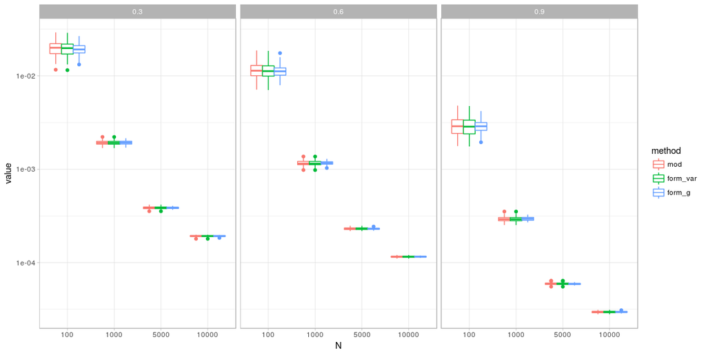

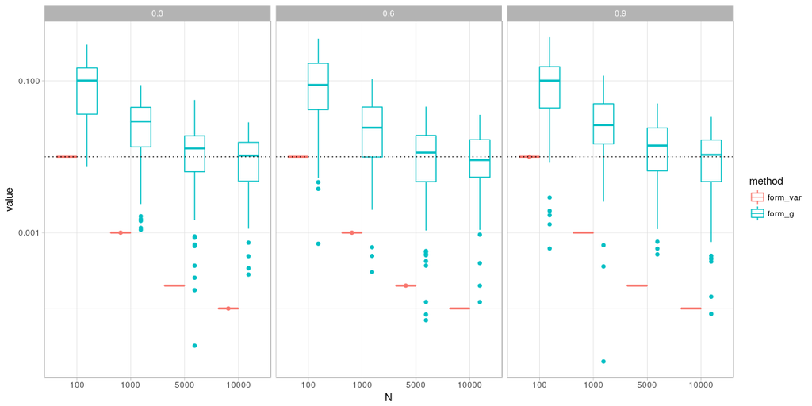

## 3.3 Genetic (additive) effect

### 3.3.1 Model

In the data simulation model here:

- Genotypes are generated according to the additive model under HW that leads to $\Sigma_x = 2pq K$.
- The genetic random effect also has the covariance matrix K, and $V = \hat{\sigma_g^2} K + \hat{\sigma_e^2} I$

$E(x_c^T V^{-1} x_c) = trace(V^{-1} \Sigma_{x_c}) = 2pq \mbox{ } trace((\hat{\sigma_g^2} K + \hat{\sigma_e^2} I)^{-1} K)$

### 3.3.2 Simulation

The parameter $\sigma_g^2$ in data simulation took the only value 0.3.

| Type | Notation | Description | R code |
| --- | --- | --- | --- |
| Exact | `mod` | Output of `lm` | `vcov(mod)["g", "g"]` |
| Approximate | `form_var` | $\frac{\sigma_{sc}^2}{N \sigma_{g*}^2}$ | `s2 / (N*var(g_tr))` |
| Approximate | `form_g` | $\frac{\sigma_{sc}^2}{tr 2pq}$ | `s2 / (trace_transform * 2*p*q))` |

- Vector $g^* = \hat{V}^{-0.5} g$ is a transformation of the vector $g$ (*not centered*).
- Scalar $tr = trace(\hat{V}^{-1}K)$ is the trace of the transformation matrix computed using EVD.

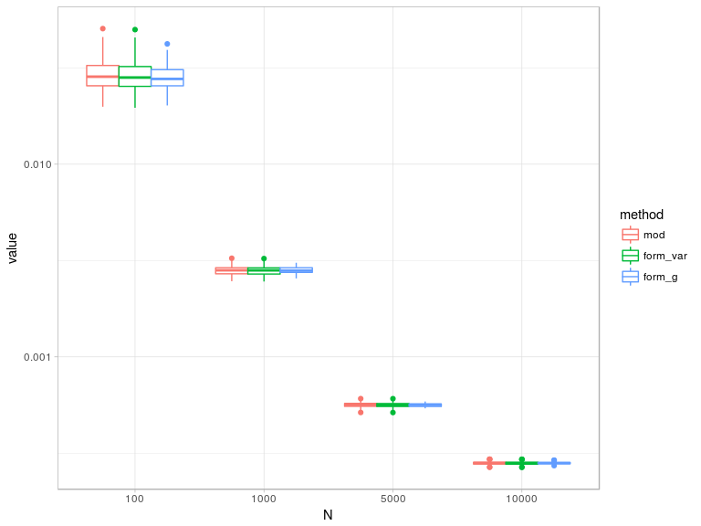

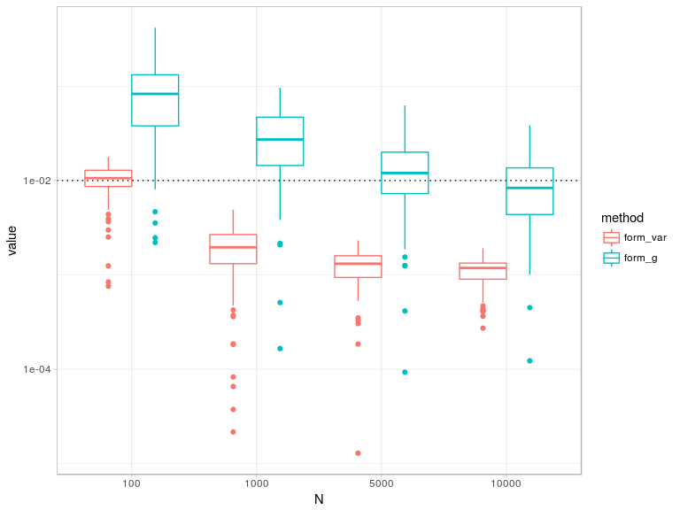

# 4 OLS for interaction effect

## 4.1 Simulation

| Type | Notation | Description | R code |
| --- | --- | --- | --- |
| Exact | `mod` | Output of `lm` | `vcov(mod)["g:e", "g:e"]` |
| Approximate | `form_var` | $\frac{\sigma_{e}^2}{N \sigma_{ge_c}^2}$ | `sigma^2 / (N*var(ge_c))` |
| Approximate | `form_g` | $\frac{\sigma_{e}^2}{N 2pq f(1-f)}$ | `sigma^2 / (N*2*p*q*f*(1-f)))` |

- Vector $ge = (g - \mu_g)(e - \mu_e)$ is the interaction values computed using *centered* genotype and environment vectors.

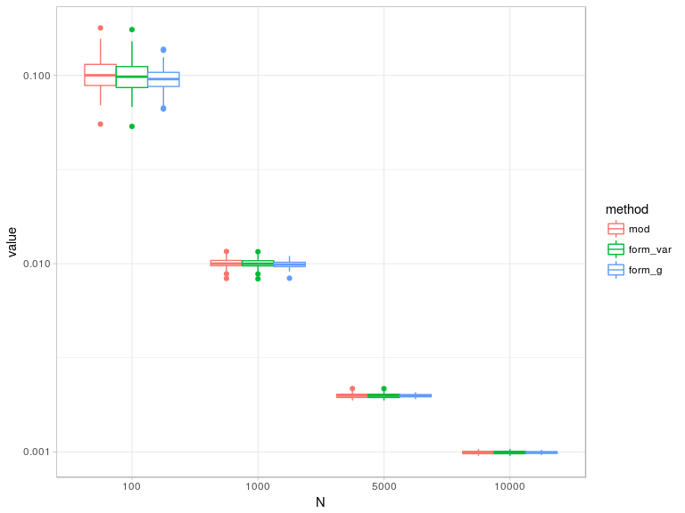

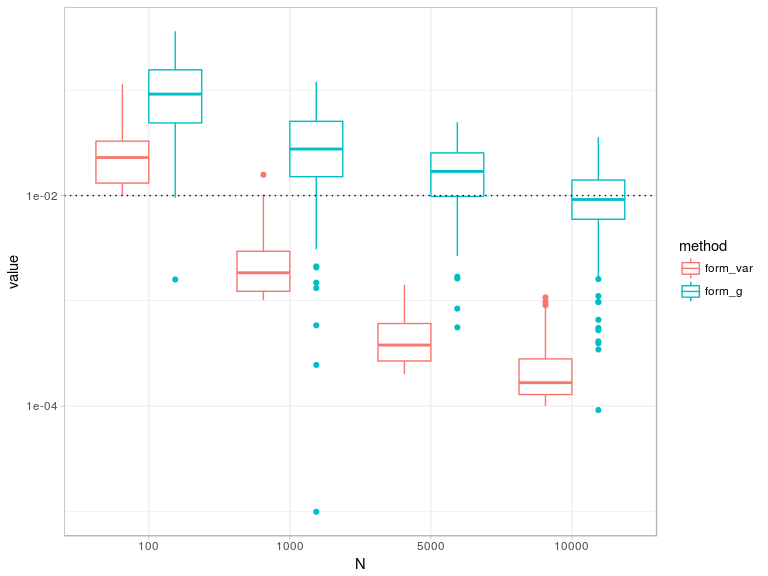

# 5 GLS for interaction effect

## 5.1 Simulation

| Type | Notation | Description | R code |
| --- | --- | --- | --- |
| Exact | `mod` | Output of `lm` | `vcov(mod)["g:e", "g:e"]` |
| Approximate | `form_var` | $\frac{\sigma_{e}^2}{N \sigma_{ge_c}^2}$ | `sigma^2 / (N*var(ge_c))` |
| Approximate | `form_g` | $\frac{\sigma_{e}^2}{N 2pq f(1-f)}$ | `sigma^2 / (N*2*p*q*f*(1-f)))` |

- Vector $ge = (g - \mu_g)(e - \mu_e)$ is the interaction values computed using *centered* genotype and environment vectors.

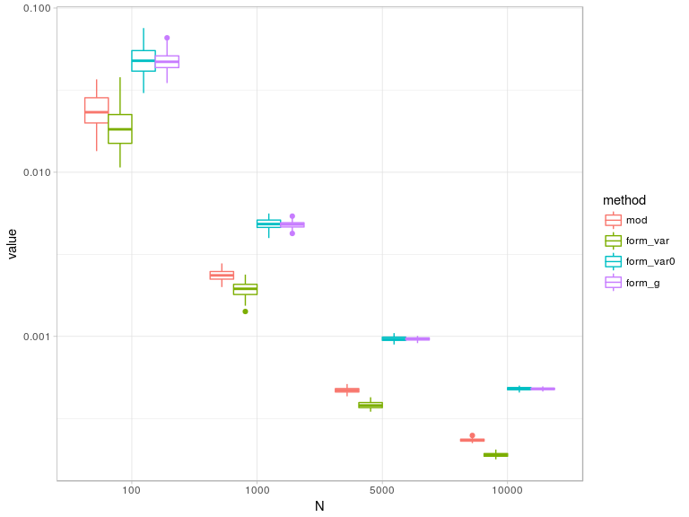

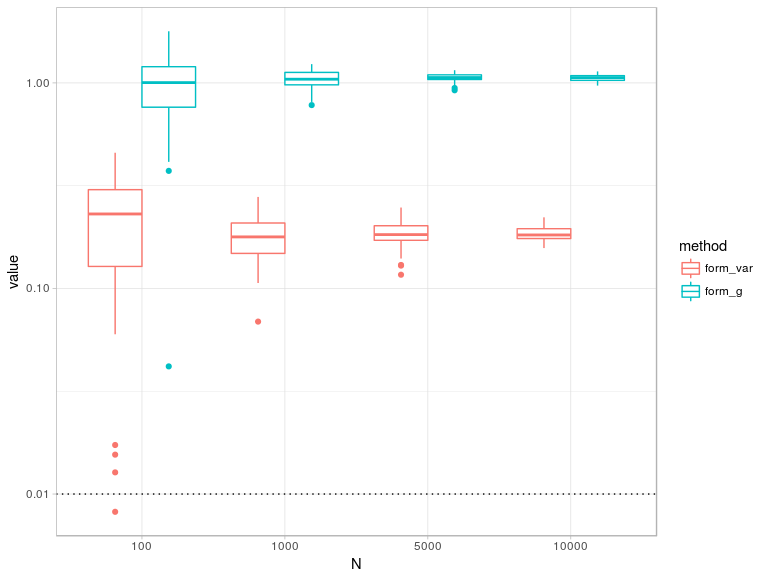

# References

Lynch, Michael, and Bruce Walsh. 1998. *Genetics and Analysis of Quantitative Traits*. Vol. 1. Sinauer Sunderland.